# EDA stroke.csv

Jiménez D. Valencia

2025-03-19

```r
library(dplyr)
library(ggplot2)
library(corrplot)
library(plotly)
library(gt)
library(broom)
library(gridExtra)
library(knitr)
library(kableExtra)
library(RColorBrewer)
```

# **Primeros vistazos**

```r
df <- read.csv("stroke.csv", stringsAsFactors = F)
head(df)
```

```
     id gender age hypertension heart_disease ever_married     work_type
1  9046   Male  67            0             1          Yes       Private
2 51676 Female  61            0             0          Yes Self-employed
3 31112   Male  80            0             1          Yes       Private
4 60182 Female  49            0             0          Yes       Private
5  1665 Female  79            1             0          Yes Self-employed
6 56669   Male  81            0             0          Yes       Private
  Residence_type avg_glucose_level  bmi  smoking_status stroke
1          Urban            228.69 36.6 formerly smoked      1
2          Rural            202.21  N/A    never smoked      1
3          Rural            105.92 32.5    never smoked      1
4          Urban            171.23 34.4          smokes      1
5          Rural            174.12   24    never smoked      1
6          Urban            186.21   29 formerly smoked      1
```

12 variables. La variable ID pareciera ser aleatoria y sin ningún valor para predecir ictus.

**Estructura y tipo de datos:**

```r
# Estructura
str(df)
```

```
'data.frame':   5110 obs. of  12 variables:
 $ id               : int  9046 51676 31112 60182 1665 56669 53882 10434 27419 60491 ...
 $ gender           : chr  "Male" "Female" "Male" "Female" ...
 $ age              : num  67 61 80 49 79 81 74 69 59 78 ...
 $ hypertension     : int  0 0 0 0 1 0 1 0 0 0 ...
 $ heart_disease    : int  1 0 1 0 0 0 1 0 0 0 ...
 $ ever_married     : chr  "Yes" "Yes" "Yes" "Yes" ...
 $ work_type        : chr  "Private" "Self-employed" "Private" "Private" ...
 $ Residence_type   : chr  "Urban" "Rural" "Rural" "Urban" ...
 $ avg_glucose_level: num  229 202 106 171 174 ...
 $ bmi              : chr  "36.6" "N/A" "32.5" "34.4" ...
 $ smoking_status   : chr  "formerly smoked" "never smoked" "never smoked" "smokes" ...
 $ stroke           : int  1 1 1 1 1 1 1 1 1 1 ...
```

5110 pacientes. variable bmi como chr, pareciera ser erróneo tenerlo con ese tipo de dato. Es preferible cambiarlo a numérico.

```r
# Convierto bmi a numérico
df$bmi <- as.numeric(df$bmi)

df <- df %>% select(-id) #aprovecho a retirar ID porque no ofrece información predictiva
```

**Conteo de valores nulos:**

```r
# Conteo de valores NA por columna
df$bmi[df$bmi == "N/A"] <- NA
colSums(is.na(df))
```

```
           gender               age      hypertension     heart_disease
                0                 0                 0                 0
     ever_married         work_type    Residence_type avg_glucose_level
                0                 0                 0                 0
              bmi    smoking_status            stroke
              201                 0                 0
```

# **Proporciones y distribuciones de variables**

## Proporción ictus(+) vs ictus(-)

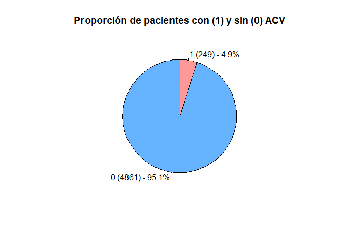

```r
# distribución de la variable 'stroke'
stroke_counts <- table(df$stroke)

# porcentajes para cada categoría
porcentajes <- round(100 * stroke_counts / sum(stroke_counts), 1)

# etiquetas
labels <- paste0(names(stroke_counts), " (", as.numeric(stroke_counts), ") - ", porcentajes, "%")

# gráfico de tortas
pie(stroke_counts,
    labels = labels,
    col = c("#66b3ff", "#ff9999"),
    main = "Proporción de pacientes con (1) y sin (0) ACV",
    init.angle = 90)
```

## Proporción HTA/cardiopatía(+) vs HTA/cardiopatía(-)

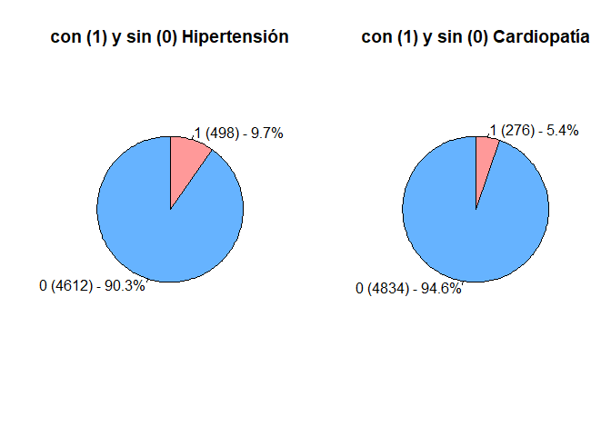

```r
par(mfrow = c(1, 2))

# Gráfico para 'hypertension'
hypertension_counts <- table(df$hypertension)
porcentajes_h <- round(100 * hypertension_counts / sum(hypertension_counts), 1)
labels_h <- paste0(names(hypertension_counts), " (", as.numeric(hypertension_counts), ") - ", porcentajes_h, "%")
pie(hypertension_counts,
    labels = labels_h,
    col = c("#66b3ff", "#ff9999"),
    main = "con (1) y sin (0) Hipertensión",
    init.angle = 90)

# Gráfico para 'heart_disease'
heart_counts <- table(df$heart_disease)
porcentajes_hd <- round(100 * heart_counts / sum(heart_counts), 1)
labels_hd <- paste0(names(heart_counts), " (", as.numeric(heart_counts), ") - ", porcentajes_hd, "%")
pie(heart_counts,
    labels = labels_hd,
    col = c("#66b3ff", "#ff9999"),
    main = "con (1) y sin (0) Cardiopatía",
    init.angle = 90)
```

## Distribución del resto de variables

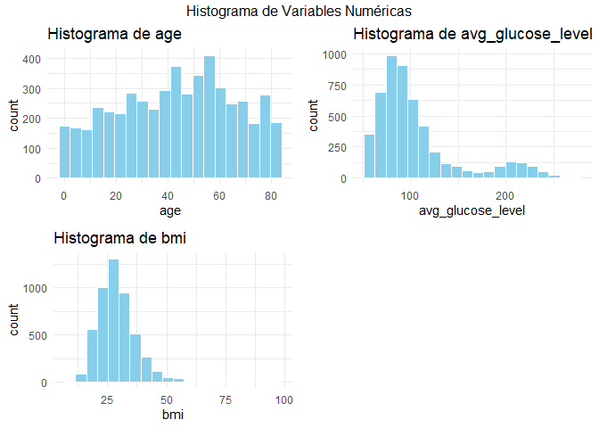

```r
cols_excluir <- c("hypertension", "heart_disease", "stroke")

numeric_cols <- setdiff(names(df)[sapply(df, is.numeric)], cols_excluir)
categorical_cols <- setdiff(names(df)[sapply(df, function(x) is.factor(x) || is.character(x))], cols_excluir)

# --- Histogramas para variables numéricas ---
plots_num <- lapply(numeric_cols, function(col) {
  ggplot(df, aes_string(x = col)) +
    geom_histogram(bins = 20, fill = "skyblue", color = "white") +
    labs(title = paste("Histograma de", col), x = col) +
    theme_minimal()
})

# Organizar los histogramas en una grilla
grid.arrange(grobs = plots_num, ncol = 2, top = "Histograma de Variables Numéricas")
```

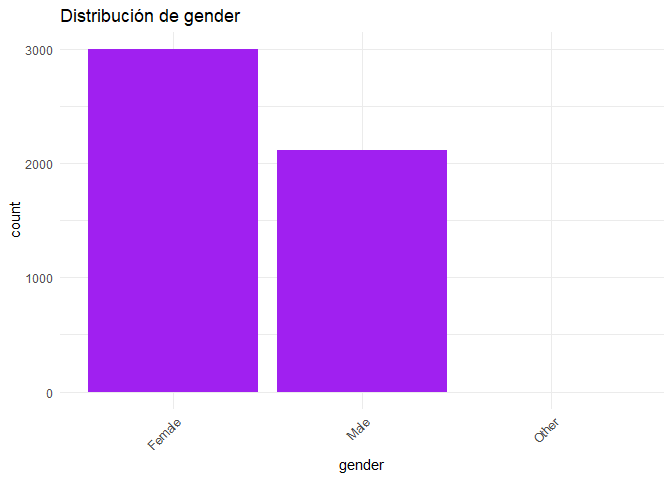

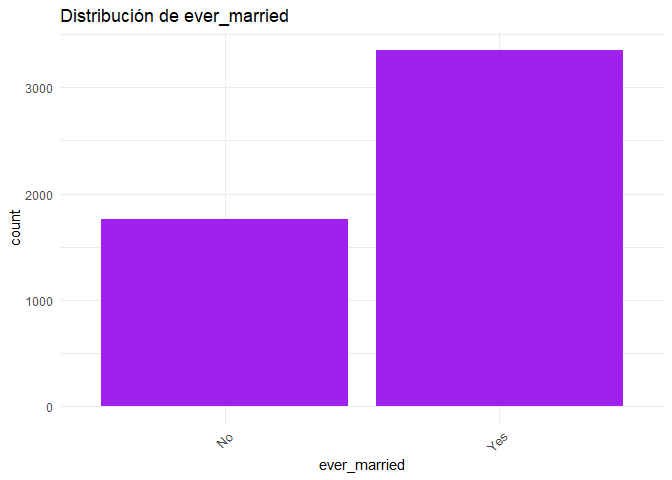

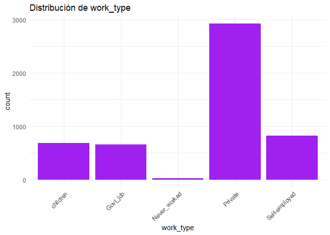

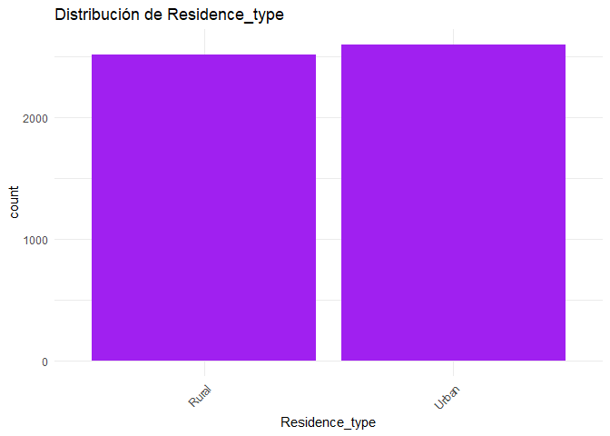

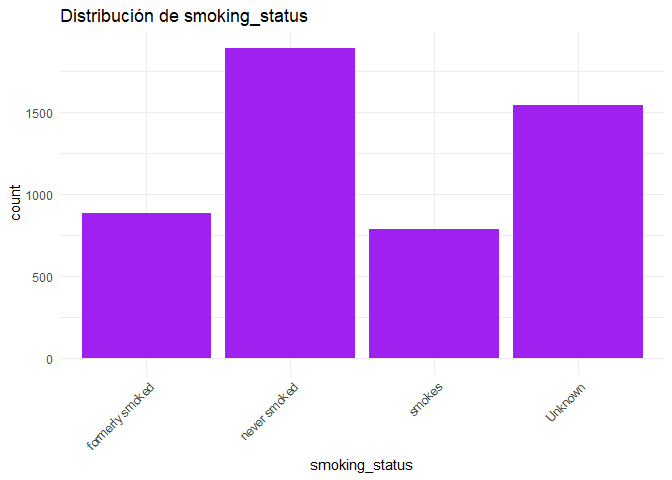

```r
# --- Gráficos de barras para variables categóricas ---
plots_cat <- lapply(categorical_cols, function(col) {
  ggplot(df, aes_string(x = col)) +
    geom_bar(fill = "purple") +
    labs(title = paste("Distribución de", col)) +
    theme_minimal() +
    theme(axis.text.x = element_text(angle = 45, hjust = 1))
})

# Imprimir cada gráfico de barras individualmente o agruparlos
for(p in plots_cat) {
  print(p)
}
```

```r
numerical_features <- c("age", "avg_glucose_level", "bmi")
summary(df[, numerical_features])
```

```
      age        avg_glucose_level      bmi
 Min.   : 0.08   Min.   : 55.12    Min.   :10.30
 1st Qu.:25.00   1st Qu.: 77.25    1st Qu.:23.50
 Median :45.00   Median : 91.89    Median :28.10
 Mean   :43.23   Mean   :106.15    Mean   :28.89
 3rd Qu.:61.00   3rd Qu.:114.09    3rd Qu.:33.10
 Max.   :82.00   Max.   :271.74    Max.   :97.60
                                   NA's   :201
```

- **age:**

La media es menor que la mediana -> Está sesgado hacia la izquierda.

- **avg_glucose_level:**

La media es mayor que la mediana -> Está sesgado hacia la derecha.

- **bmi:**

La media es mayor que la mediana -> Está sesgado hacia la derecha.

Me llama la atención el bmi mínimo: 10.3 y el bmi máximo: 97.60 Sobretodo este último, es un valor bastante raro desde el punto de vista clínico y estadístico. Debo estudiarlos más adelante

### Estudio de normalidad de variables contínuas

*Variables continuas parecieran no seguir distribución normal*

**Se puede observar mejor en un Q-Q plot:**

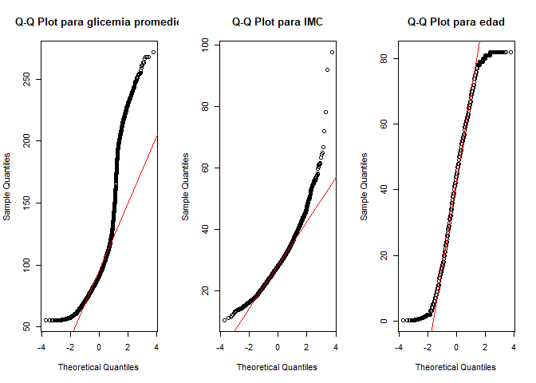

```r
par(mfrow = c(1, 3))
# Q-Q plot para la variable 'avg_glucose_level'
qqnorm(df$avg_glucose_level, main = "Q-Q Plot para glicemia promedio")
qqline(df$avg_glucose_level, col = "red")

# Q-Q plot para la variable 'bmi'
qqnorm(df$bmi, main = "Q-Q Plot para IMC")
qqline(df$bmi, col = "red")

# Q-Q plot para la variable 'age'
qqnorm(df$age, main = "Q-Q Plot para edad")
qqline(df$age, col = "red")
```

**Prueba de Shapiro-wilk:**

```r
# Función para aplicar Shapiro-Wilk controlando el tamaño de la muestra
aplicar_shapiro <- function(x) {
  datos <- na.omit(x)
  n <- length(datos)

  if(n < 3) {
    cat("No hay suficientes observaciones (", n, ") para realizar el test de Shapiro-Wilk.\n")
    return(NULL)
  } else if(n > 5000) {
    set.seed(123)  # para reproducibilidad
    datos <- sample(datos, 5000)
    cat("Se tomó una muestra aleatoria de 5000 observaciones para el test de Shapiro-Wilk.\n")
  }

  test <- shapiro.test(datos)
  return(test)
}

# Lista de variables a evaluar
numeric_vars <- c("age", "avg_glucose_level", "bmi")

for (var in numeric_vars) {
  cat("📊 **Shapiro-Wilk para", var, ":**\n")
  test <- aplicar_shapiro(df[[var]])
  if (!is.null(test)) {
    cat("   - Estadístico W:", round(test$statistic, 4), "\n")
    cat("   - p-value:", round(test$p.value, 4), "\n")

    if (test$p.value < 0.05) {
      cat("   ❌ Se rechaza H0:", var, "**no sigue** una distribución normal.\n\n")
    } else {
      cat("   ✅ No se rechaza H0:", var, "**podría seguir** una distribución normal.\n\n")
    }
  }
}
```

```
📊 **Shapiro-Wilk para age :**
Se tomó una muestra aleatoria de 5000 observaciones para el test de Shapiro-Wilk.
   - Estadístico W: 0.9668
   - p-value: 0
   ❌ Se rechaza H0: age **no sigue** una distribución normal.

📊 **Shapiro-Wilk para avg_glucose_level :**
Se tomó una muestra aleatoria de 5000 observaciones para el test de Shapiro-Wilk.
   - Estadístico W: 0.806
   - p-value: 0
   ❌ Se rechaza H0: avg_glucose_level **no sigue** una distribución normal.

📊 **Shapiro-Wilk para bmi :**
   - Estadístico W: 0.9535
   - p-value: 0
   ❌ Se rechaza H0: bmi **no sigue** una distribución normal.
```

*Prueba de Shapiro-wilk respalda lo observado*

# Búsqueda de outliers

## Boxplots de variables continuas

```
avg_glucose_level - Número de outliers: 627
```

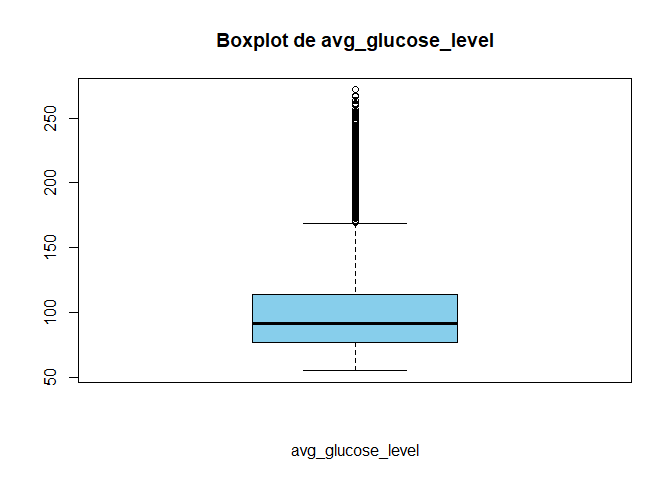

```
bmi - Número de outliers: 311
```

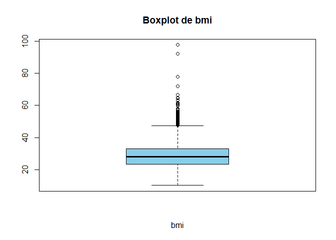

```
age - Número de outliers: 0
```

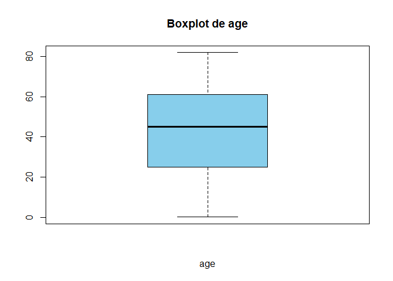

```r
# Lista de variables a evaluar
variables <- c("avg_glucose_level", "bmi", "age")

for (var in variables) {
  # Calcular Q1, Q3 e IQR
  Q1 <- quantile(df[[var]], 0.25, na.rm = TRUE)
  Q3 <- quantile(df[[var]], 0.75, na.rm = TRUE)
  IQR_value <- Q3 - Q1

  # Calcular límites para detectar outliers
  lower_bound <- Q1 - 1.5 * IQR_value
  upper_bound <- Q3 + 1.5 * IQR_value

  # Filtrar outliers
  outliers <- df[df[[var]] < lower_bound | df[[var]] > upper_bound, ]
  cat(var, "- Número de outliers:", nrow(outliers), "\n")

  # Graficar diagrama de caja
  boxplot(df[[var]],
          main = paste("Boxplot de", var),
          col = "skyblue",
          xlab = var)
}
```

## Violinplots de variables continuas

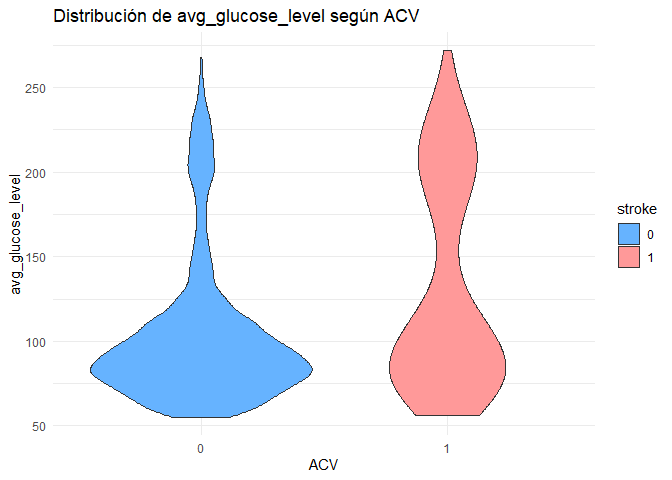

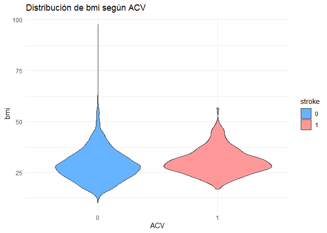

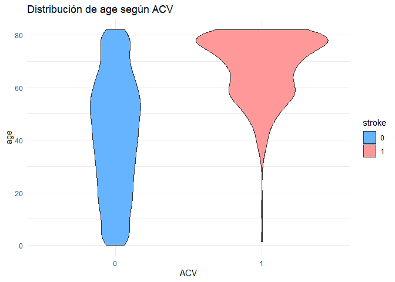

```r
# Asegurar que stroke es un factor con orden "0" y "1"
df$stroke <- factor(df$stroke, levels = c("0", "1"))

# Lista de variables a evaluar
variables <- c("avg_glucose_level", "bmi", "age")

for (col in variables) {
  p <- ggplot(df, aes_string(x = "stroke", y = col, fill = "stroke")) +
    geom_violin() +
    scale_fill_manual(values = c("0" = "#66b3ff", "1" = "#ff9999")) +
    labs(title = paste("Distribución de", col, "según ACV"),
         x = "ACV",
         y = col) +
    theme_minimal()

  print(p)
}
```

## Valores Atípicos de IMC

**Observo características de aquellos con bmi menores a 11 y mayores a 70:**

```r
# Filtrar casos extremos: bmi > 70 o bmi < 11
subset_df <- df %>% filter(bmi > 70 | bmi < 11)

# Tabla
subset_df %>%
  kable(caption = "Características de IMC extremos") %>%
  kable_styling(bootstrap_options = c("striped", "hover", "condensed", "responsive"))
```

Características de IMC extremos

| gender | age | hypertension | heart_disease | ever_married | work_type | Residence_type | avg_glucose_level | bmi | smoking_status | stroke |
| --- | --- | --- | --- | --- | --- | --- | --- | --- | --- | --- |
| Male | 42.00 | 0 | 0 | Yes | Private | Rural | 210.48 | 71.9 | never smoked | 0 |
| Female | 23.00 | 1 | 0 | No | Private | Urban | 70.03 | 78.0 | smokes | 0 |
| Female | 1.24 | 0 | 0 | No | children | Rural | 122.04 | 10.3 | Unknown | 0 |
| Male | 17.00 | 1 | 0 | No | Private | Rural | 61.67 | 97.6 | Unknown | 0 |
| Male | 38.00 | 1 | 0 | Yes | Private | Rural | 56.90 | 92.0 | never smoked | 0 |

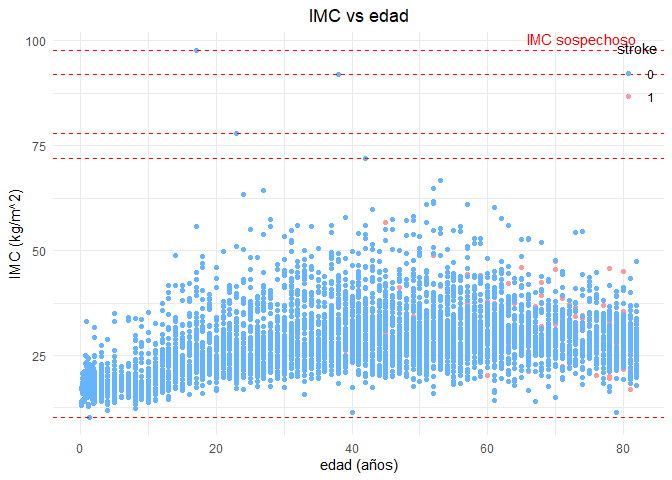

```r
df$stroke <- factor(df$stroke, levels = c("0", "1"))

p <- ggplot(df, aes(x = age, y = bmi, color = stroke)) +
  geom_point() +
  scale_color_manual(values = c("0" = "#66b3ff", "1" = "#ff9999")) +
  geom_hline(yintercept = 97.6, color = "red", linetype = "dashed") +
  geom_hline(yintercept = 92.0, color = "red", linetype = "dashed") +
  geom_hline(yintercept = 71.9, color = "red", linetype = "dashed") +
  geom_hline(yintercept = 78.0, color = "red", linetype = "dashed") +
  geom_hline(yintercept = 10.3, color = "red", linetype = "dashed") +
  ggtitle("IMC vs edad") +
  xlab("edad (años)") +
  ylab("IMC (kg/m^2)") +
  theme_minimal() +
  theme(plot.title = element_text(hjust = 0.5),
        legend.position = c(1, 1),
        legend.justification = c(1, 1))

# Indicar "IMC sospechoso"
p <- p + annotate("text",
                  x = max(df$age, na.rm = TRUE),
                  y = 97.6,
                  label = "IMC sospechoso",
                  color = "red",
                  hjust = 1,
                  vjust = -0.5)

print(p)
```

Decido retirar los IMC> 70… el IMC de 10.3 se eliminará luego, ya que retiraré a los menores de 5 años Esto se hará en la etapa de **Preprocesamiento**, pero lo haré en python, en el Jupyter Notebook

# **Pruebas de Asociación**

*Como las variables continuas no siguen una distribución normal, utilizaré Mann-Whitney, que es una prueba no paramétrica.*

## Prueba U de Mann-Whitney:

```r
variables <- c("age", "bmi", "avg_glucose_level")

for (col in variables) {
  # Dividir en grupos según la variable stroke
  grupo_stroke_0 <- df[df$stroke == 0, col]
  grupo_stroke_1 <- df[df$stroke == 1, col]

  # Aplicar el test de Wilcoxon (Mann-Whitney) con alternativa bilateral
  test <- wilcox.test(grupo_stroke_0, grupo_stroke_1, alternative = "two.sided")

  cat("\n📊 **Prueba U de Mann-Whitney para", col, ":**\n")
  cat("   - Estadístico W:", round(test$statistic, 4), "\n")
  cat("   - p-value:", round(test$p.value, 6), "\n")

  if (test$p.value < 0.05) {
    cat("   ✅ Diferencia significativa en", col, "entre grupos (stroke=0 vs stroke=1)\n")
  } else {
    cat("   ❌ No se detecta diferencia significativa en", col, "\n")
  }
}
```

```
📊 **Prueba U de Mann-Whitney para age :**
   - Estadístico W: 200263.5
   - p-value: 0
   ✅ Diferencia significativa en age entre grupos (stroke=0 vs stroke=1)

📊 **Prueba U de Mann-Whitney para bmi :**
   - Estadístico W: 413278.5
   - p-value: 0.000103
   ✅ Diferencia significativa en bmi entre grupos (stroke=0 vs stroke=1)

📊 **Prueba U de Mann-Whitney para avg_glucose_level :**
   - Estadístico W: 471239
   - p-value: 0
   ✅ Diferencia significativa en avg_glucose_level entre grupos (stroke=0 vs stroke=1)
```

Se observa relación entre las variables imc, glicemia promedio y edad con ACV.

**Estudio la fuerza de esa relación con prueba de Spearmen y Kendall:**

```r
#primero omito los valores NA
 df <- na.omit(df)
```

```r
variables <- c("age", "bmi", "avg_glucose_level")

for (col in variables) {
  # Convertir 'stroke' a numérico sin modificar el data frame:
  stroke_num <- as.numeric(as.character(df$stroke))

  # Calcular correlación de Spearman
  spearman_result <- cor.test(df[[col]], stroke_num, method = "spearman")
  # Calcular correlación de Kendall
  kendall_result <- cor.test(df[[col]], stroke_num, method = "kendall")

  cat("\n🔎 **Correlación de", col, "con stroke**\n")
  cat("   - Spearman: r =", round(spearman_result$estimate, 4),
      ", p-value =", format(spearman_result$p.value, digits = 6), "\n")
  cat("   - Kendall:  τ =", round(kendall_result$estimate, 4),
      ", p-value =", format(kendall_result$p.value, digits = 6), "\n")

  if (spearman_result$p.value < 0.05) {
    cat("   ✅", col, "tiene correlación significativa con stroke según Spearman.\n")
  } else {
    cat("   ❌ No hay correlación significativa de", col, "con stroke (Spearman).\n")
  }

  if (kendall_result$p.value < 0.05) {
    cat("   ✅", col, "tiene correlación significativa con stroke según Kendall.\n")
  } else {
    cat("   ❌ No hay correlación significativa de", col, "con stroke (Kendall).\n")
  }
}
```

```
🔎 **Correlación de age con stroke**
   - Spearman: r = 0.2351 , p-value = 1.30328e-62
   - Kendall:  τ = 0.1931 , p-value = 6.1977e-61
   ✅ age tiene correlación significativa con stroke según Spearman.
   ✅ age tiene correlación significativa con stroke según Kendall.
```

```
🔎 **Correlación de bmi con stroke**
   - Spearman: r = 0.0554 , p-value = 0.000101625
   - Kendall:  τ = 0.0454 , p-value = 0.000102632
   ✅ bmi tiene correlación significativa con stroke según Spearman.
   ✅ bmi tiene correlación significativa con stroke según Kendall.
```

```
🔎 **Correlación de avg_glucose_level con stroke**
   - Spearman: r = 0.0877 , p-value = 7.62452e-10
   - Kendall:  τ = 0.0716 , p-value = 8.16717e-10
   ✅ avg_glucose_level tiene correlación significativa con stroke según Spearman.
   ✅ avg_glucose_level tiene correlación significativa con stroke según Kendall.
```

*Las variables binarias están bastante desbalanceadas, así que un chi-cuadrado no sería ideal, sino más bien un test de fisher*

## Prueba exacta de Fisher

```r
# Crear tabla de contingencia para hipertensión vs ACV
tabla_hipertension <- table(df$hypertension, df$stroke)
fisher_hyper <- fisher.test(tabla_hipertension)

# Crear tabla de contingencia para cardiopatía vs ACV
tabla_heart <- table(df$heart_disease, df$stroke)
fisher_heart <- fisher.test(tabla_heart)

# Mostrar resultados
cat("Resultados de la Prueba Exacta de Fisher:\n")
```

```
Resultados de la Prueba Exacta de Fisher:
```

```r
cat("Hipertensión vs ACV:\n")
```

```
Hipertensión vs ACV:
```

```r
cat(sprintf("Odds Ratio: %.4f, p-value: %.6f\n", fisher_hyper$estimate, fisher_hyper$p.value))
```

```
Odds Ratio: 4.4356, p-value: 0.000000
```

```r
cat("\nCardiopatía vs ACV:\n")
```

```
Cardiopatía vs ACV:
```

```r
cat(sprintf("Odds Ratio: %.4f, p-value: %.6f\n", fisher_heart$estimate, fisher_heart$p.value))
```

```
Odds Ratio: 5.2398, p-value: 0.000000
```

Los resultados de la prueba exacta de Fisher muestran que tanto la HTA como la cardiopatía están fuertemente asociadas con la presencia de ACV.

- Los pacientes con HTA tienen aproximadamente 4.44 veces mayor probabilidad de sufrir un ACV en comparación con aquellos sin HTA.
- Los pacientes con cardiopatía tienen aproximadamente 5.24 veces mayor probabilidad de sufrir un ACV en comparación con aquellos sin cardiopatía.

## Prueba de Chi-Cuadrado:

**Además se medirá fuerza de relación con V de Cramér**

```r
# Lista de variables categóricas a evaluar
variables <- c("smoking_status", "ever_married", "Residence_type", "work_type")

for (var in variables) {
  cat("Variable:", var, "\n")

  # Crear la tabla de contingencia
  tabla <- table(df[[var]], df$stroke)
  cat("Tabla de contingencia:\n")
  print(tabla)

  # Aplicar la prueba de Chi-Cuadrado
  test <- chisq.test(tabla)
  chi2 <- test$statistic
  p_value <- test$p.value
  dof <- test$parameter

  cat(sprintf("Chi2: %.4f, p-value: %.6f, dof: %d\n", chi2, p_value, dof))
  cat("Tabla de frecuencias esperadas:\n")
  print(test$expected)

  # Calcular Cramér's V:
  # V = sqrt(chi2 / (n * min(r-1, c-1)))
  n <- sum(tabla)  # total de observaciones
  r <- nrow(tabla)
  c <- ncol(tabla)
  min_dim <- min(r - 1, c - 1)
  if (min_dim > 0) {
    cramers_v <- sqrt(chi2 / (n * min_dim))
  } else {
    cramers_v <- NA
  }
  cat(sprintf("Cramér's V: %.4f\n", cramers_v))

  cat(strrep("-", 50), "\n\n")
}
```

```
Variable: smoking_status
Tabla de contingencia:

                     0    1
  formerly smoked  780   57
  never smoked    1768   84
  smokes           698   39
  Unknown         1454   29
Chi2: 34.9435, p-value: 0.000000, dof: 3
Tabla de frecuencias esperadas:

                          0        1
  formerly smoked  801.3648 35.63516
  never smoked    1773.1514 78.84865
  smokes           705.6223 31.37767
  Unknown         1419.8615 63.13852
Cramér's V: 0.0844
--------------------------------------------------

Variable: ever_married
Tabla de contingencia:

         0    1
  No  1682   23
  Yes 3018  186
Chi2: 53.1259, p-value: 0.000000, dof: 1
Tabla de frecuencias esperadas:

            0         1
  No  1632.41  72.59014
  Yes 3067.59 136.40986
Cramér's V: 0.1040
--------------------------------------------------

Variable: Residence_type
Tabla de contingencia:

           0    1
  Rural 2319  100
  Urban 2381  109
Chi2: 0.1238, p-value: 0.724923, dof: 1
Tabla de frecuencias esperadas:

               0        1
  Rural 2316.011 102.9886
  Urban 2383.989 106.0114
Cramér's V: 0.0050
--------------------------------------------------

Variable: work_type
Tabla de contingencia:

                   0    1
  children       670    1
  Govt_job       602   28
  Never_worked    22    0
  Private       2684  127
  Self-employed  722   53
```

```
Chi2: 41.9535, p-value: 0.000000, dof: 4
Tabla de frecuencias esperadas:

                         0          1
  children       642.43227  28.567733
  Govt_job       603.17784  26.822163
  Never_worked    21.06335   0.936647
  Private       2691.32206 119.677938
  Self-employed  742.00448  32.995518
Cramér's V: 0.0924
--------------------------------------------------
```

## Efecto moderador de la edad en las asociaciones

### Proporción de casados según edad

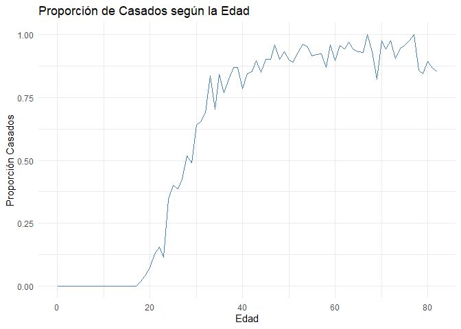

```r
# Calcular la proporción de 'Yes' en ever_married por edad
df_proportion <- df %>%
  group_by(age) %>%
  summarise(ever_married = mean(ever_married == "Yes")) %>%
  ungroup()

# Graficar la proporción de casados según la edad
ggplot(df_proportion, aes(x = age, y = ever_married)) +
  geom_line(color = "steelblue") +
  labs(title = "Proporción de Casados según la Edad",
       x = "Edad",
       y = "Proporción Casados") +
  theme_minimal()
```

La aparente relación entre el estado civil y la presencia de ACV está mediada por la edad, ya que, como se observa en el gráfico, hay un cierto valor de edad en donde la proporción de casados se dispara. Y, como ya se observó anteriormente, hay una relación estrecha entre la edad y presencia de ACV.

### Proporción del tipo de empleo según edad

```r
df$stroke <- as.numeric(as.character(df$stroke))
df_work_acv <- df %>%
  group_by(work_type) %>%
  summarise(proporcion_ACV = mean(stroke)) %>%
  ungroup()

print(df_work_acv)
```

```
# A tibble: 5 × 2
  work_type     proporcion_ACV
  <chr>                  <dbl>
1 Govt_job             0.0444
2 Never_worked         0
3 Private              0.0452
4 Self-employed        0.0684
5 children             0.00149
```

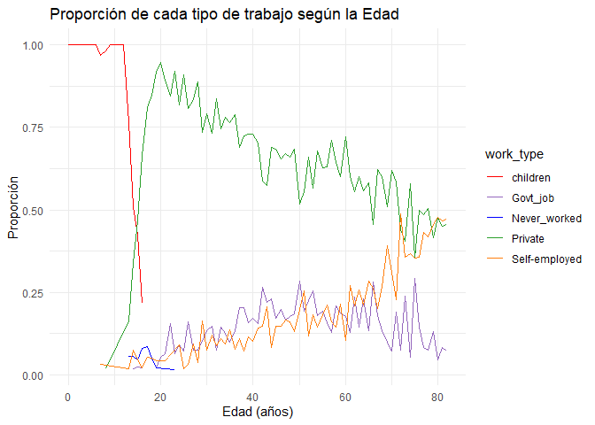

```r
# Crear df_merged: agrupar por edad y tipo de trabajo y calcular la proporción
df_merged <- df %>%
  group_by(age, work_type) %>%
  summarise(count = n()) %>%
  group_by(age) %>%
  mutate(proportion = count / sum(count)) %>%
  ungroup()

# Mapa de colores personalizado
custom_palette <- c(
  "children" = "red",
  "Self-employed" = "#ff7f0e",  # Color original
  "Private" = "#2ca02c",        # Color original
  "Never_worked" = "blue",
  "Govt_job" = "#9467bd"        # Color original
)

# Graficar con los colores personalizados
ggplot(df_merged, aes(x = age, y = proportion, color = work_type)) +
  geom_line() +
  scale_color_manual(values = custom_palette) +
  labs(
    title = "Proporción de cada tipo de trabajo según la Edad",
    x = "Edad (años)",
    y = "Proporción",
    color = "work_type"
  ) +
  theme_minimal()
```

La edad también tiene efecto moderador entre tipo de empleo y acv: Se observa en la tabla, que los trabajadores independientes tienen mayor proporción de ACV que el resto de los tipos de empleo. También se observa que aquellos que nunca han trabajado, ninguno ha tenido ACV. Pero, al visualizarlo en el gráfico de proporción de cada tipo de trabajo según la edad, se aprecia claramente que la mayor proporción de trabajadores independientes se encuentra en la mayoría de edad, mientras que aquellos que nunca han trabajado se encuentran en el rango etario de adolescente y adulto joven.

```r
# Convertir variables: work_type a factor y stroke a entero (binario)
df$work_type <- as.factor(df$work_type)
#df$stroke <- as.integer(df$stroke)

# Ajustar el modelo de regresión logística
model <- glm(stroke ~ work_type + age, data = df, family = binomial(link = "logit"),
             control = list(maxit = 100))

# Extraer coeficientes del modelo
coefs <- summary(model)$coefficients

# Calcular Odds Ratios (transformando los coeficientes a la escala de OR)
odds_ratios <- exp(coefs[, "Estimate"])

# Calcular intervalos de confianza al 95%
ci <- exp(confint(model))  # alternativamente, puedes usar confint.default(model)

# Crear tabla de resultados con Odds Ratio, intervalos de confianza y p-value
results <- data.frame(
  Odds_Ratio = odds_ratios,
  Lower_95  = ci[, 1],
  Upper_95  = ci[, 2],
  p_value   = coefs[, "Pr(>|z|)"]
)

print(results)
```

```
                         Odds_Ratio     Lower_95     Upper_95      p_value
(Intercept)            8.143819e-04 4.635385e-05 3.607456e-03 1.261062e-12
work_typeGovt_job      5.791424e-01 1.048633e-01 1.086721e+01 6.100073e-01
work_typeNever_worked  5.890263e-05 1.275335e-60 5.300872e-57 9.749079e-01
work_typePrivate       6.925305e-01 1.306325e-01 1.282352e+01 7.281826e-01
work_typeSelf-employed 4.480451e-01 7.971550e-02 8.460190e+00 4.560121e-01
age                    1.081888e+00 1.070039e+00 1.094540e+00 2.290028e-42
```

- **Estado civil:**

```r
# Convertir variables: 'ever_married' como factor y 'stroke' como entero (0/1)
df$ever_married <- as.factor(df$ever_married)
#df$stroke <- as.integer(df$stroke)

# Ajustar el modelo de regresión logística
model <- glm(stroke ~ ever_married + age, data = df, family = binomial(link = "logit"))

# Extraer coeficientes y calcular Odds Ratios
coefs <- summary(model)$coefficients
odds_ratios <- exp(coefs[, "Estimate"])

# Calcular intervalos de confianza al 95%
ci <- exp(confint(model))  # Utiliza el perfil de verosimilitud; alternativamente, confint.default(model)

# Crear tabla de resultados con Odds Ratio, intervalos de confianza y p-value
results <- data.frame(
  `Odds Ratio` = odds_ratios,
  `[0.025]`   = ci[, 1],
  `[0.975]`   = ci[, 2],
  `P>|z|`     = coefs[, "Pr(>|z|)"]
)

print(results)
```

```
                  Odds.Ratio     X.0.025.   X.0.975.        P..z.
(Intercept)     0.0006572376 0.0002925058 0.00136651 1.202843e-77
ever_marriedYes 0.9274939992 0.5914079723 1.51455365 7.526007e-01
age             1.0781330483 1.0671420912 1.08984356 1.004737e-44
```

### Probabilidad de ACV según HTA/Cardiopatía/Estatus Fumador vs Edad

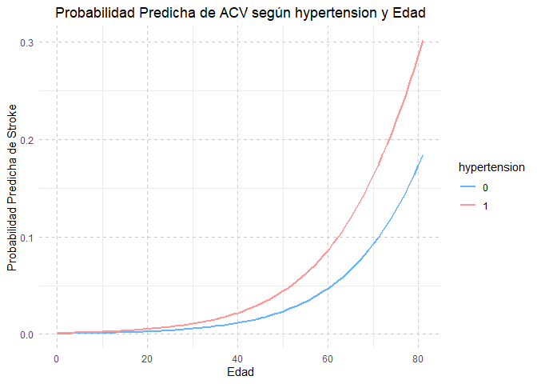

```r
library(ggplot2)
library(RColorBrewer)

analyze_variable <- function(var_name, custom_palette = NULL) {
  # Asegurarse de que la variable de interés sea factor (sin modificar stroke)
  if (!is.factor(df[[var_name]])) {
    df[[var_name]] <<- as.factor(df[[var_name]])
  }

  # Crear un rango de edad (desde el mínimo hasta el máximo)
  age_range <- seq(min(df$age, na.rm = TRUE), max(df$age, na.rm = TRUE), by = 1)

  # Obtener los niveles de la variable
  var_levels <- levels(df[[var_name]])

  # Crear un data frame de predicción con todas las combinaciones de edad y niveles de la variable
  prediction_data <- expand.grid(age = age_range, tmp = var_levels)
  names(prediction_data)[names(prediction_data) == "tmp"] <- var_name

  # Ajustar el modelo de regresión logística
  # Se utiliza la fórmula: stroke ~ age + factor(var_name)
  formula_str <- paste("stroke ~ age + factor(", var_name, ")", sep = "")
  model <- glm(as.formula(formula_str), data = df, family = binomial(link = "logit"))

  # Generar probabilidades predichas (en la escala de respuesta, ya que 'stroke' se asume correcto)
  prediction_data$predicted_prob <- predict(model, newdata = prediction_data, type = "response")

  # Definir paleta de colores personalizada si no se provee
  if (is.null(custom_palette)) {
    if (length(var_levels) == 2) {
      custom_palette <- c("0" = "#66b3ff", "1" = "#ff9999")
    } else {
      # Si la variable tiene más de dos niveles, usar la paleta Set1 de RColorBrewer
      colors <- brewer.pal(n = min(9, length(var_levels)), name = "Set1")
      if (length(var_levels) > length(colors)) {
        colors <- rep(colors, length.out = length(var_levels))
      }
      names(colors) <- var_levels
      custom_palette <- colors
    }
  }

  # Graficar: Probabilidad predicha de Stroke vs edad, diferenciada por niveles de la variable
  p <- ggplot(prediction_data, aes_string(x = "age", y = "predicted_prob", color = var_name)) +
    geom_line(size = 1) +
    labs(title = paste("Probabilidad Predicha de ACV según", var_name, "y Edad"),
         x = "Edad",
         y = "Probabilidad Predicha de Stroke",
         color = var_name) +
    scale_color_manual(values = custom_palette) +
    theme_minimal() +
    theme(panel.grid.major = element_line(color = "grey80", linetype = "dashed"),
          plot.title = element_text(hjust = 0.5))

  print(p)
}

# Ejemplos de uso:
# Se asume que df$stroke ya está correctamente codificada (sin modificaciones adicionales).
analyze_variable("hypertension")
```

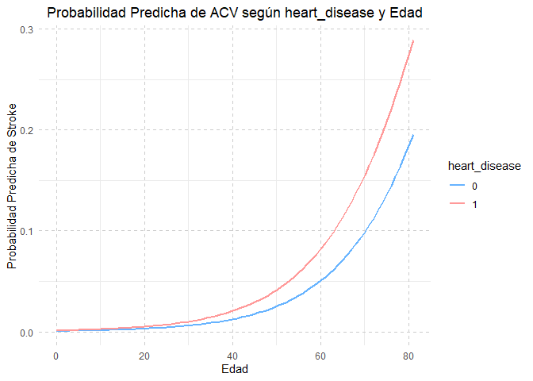

```r
analyze_variable("heart_disease")
```

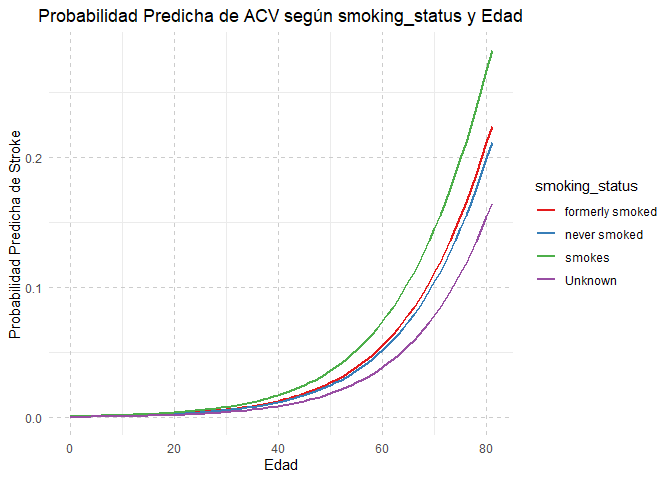

```r
analyze_variable("smoking_status")
```

Se aprecia que la probabilidad de ACV aumenta con los esas variables independientemente de la edad.

Añadiré la sombra de intervalo de confianza:

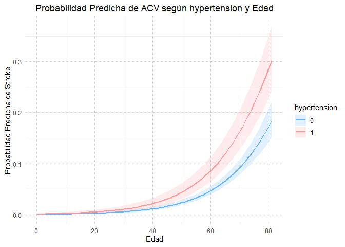

```r
analyze_variable <- function(var_name) {
  # Asegurarte de que la variable sea factor
  if (!is.factor(df[[var_name]])) {
    df[[var_name]] <<- as.factor(df[[var_name]])
  }

  # Crear un rango de edad (de mínimo a máximo, paso 1)
  age_range <- seq(min(df$age, na.rm = TRUE), max(df$age, na.rm = TRUE), by = 1)

  # Obtener los niveles de la variable
  var_levels <- levels(df[[var_name]])

  # Crear un dataframe de predicción con todas las combinaciones de edad y niveles de la variable
  prediction_data <- expand.grid(
    age = age_range,
    tmp = var_levels
  )
  names(prediction_data)[names(prediction_data) == "tmp"] <- var_name

  # Ajustar el modelo de regresión logística con glm()
  # Forzamos la variable como factor para que sea equivalente a C(var_name) en Python
  formula_str <- paste("stroke ~ age + factor(", var_name, ")", sep = "")
  model <- glm(as.formula(formula_str), data = df, family = binomial(link = "logit"))

  # Calcular predicciones en la escala del vínculo (logit) y sus errores estándar
  pred_link <- predict(model, newdata = prediction_data, type = "link", se.fit = TRUE)

  # Guardar valores en el dataframe de predicción
  prediction_data$fit_link <- pred_link$fit      # predicción en escala logit
  prediction_data$se_link  <- pred_link$se.fit   # error estándar en escala logit

  # Transformar a la escala de probabilidad con la función logística
  # y calcular el IC del 95%
  prediction_data$predicted_prob <- plogis(prediction_data$fit_link)
  prediction_data$lower <- plogis(prediction_data$fit_link - 1.96 * prediction_data$se_link)
  prediction_data$upper <- plogis(prediction_data$fit_link + 1.96 * prediction_data$se_link)

  # Definir paleta de colores
  # Si la variable solo tiene 2 niveles ("0" y "1"), se usa una paleta fija.
  # Si tiene más niveles (p.ej. smoking_status), usaremos brewer.pal para asignar colores.
  if (length(var_levels) == 2) {
    custom_palette <- c("0" = "#66b3ff", "1" = "#ff9999")
  } else {
    # Para más niveles, seleccionamos una paleta "Set1"
    colors <- brewer.pal(n = min(9, length(var_levels)), name = "Set1")
    if (length(var_levels) > length(colors)) {
      colors <- rep(colors, length.out = length(var_levels))
    }
    names(colors) <- var_levels
    custom_palette <- colors
  }

  # Graficar los resultados con ggplot2
  # Se dibuja la línea y se sombrea el intervalo de confianza con geom_ribbon()
  p <- ggplot(prediction_data,
              aes_string(x = "age", y = "predicted_prob",
                         color = var_name, fill = var_name, group = var_name)) +
    geom_line(size = 1) +
    geom_ribbon(aes(ymin = lower, ymax = upper), alpha = 0.2, color = NA) +
    scale_color_manual(values = custom_palette) +
    scale_fill_manual(values = custom_palette) +
    labs(title = paste("Probabilidad Predicha de ACV según", var_name, "y Edad"),
         x = "Edad",
         y = "Probabilidad Predicha de Stroke",
         color = var_name) +
    theme_minimal() +
    theme(
      panel.grid.major = element_line(color = "grey80", linetype = "dashed"),
      plot.title = element_text(hjust = 0.5)
    )

  print(p)
}

# Ejemplos de uso:
analyze_variable("hypertension")
```

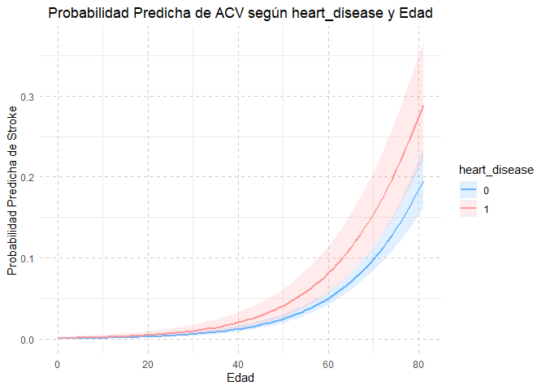

```r
analyze_variable("heart_disease")
```

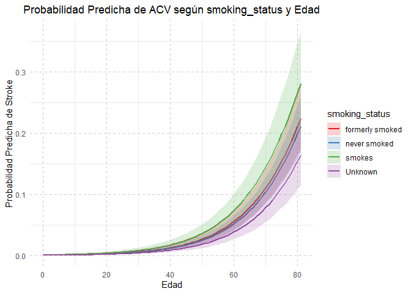

```r
analyze_variable("smoking_status")
```

En los gráficos de análisis de predicción de probabilidades condicionales mediante regresión logística, se observa que la probabilidad de ACV son mayores en los pacientes con hipertensión, cardiopatías y fumadores, independientemente de la edad. Aunque es menos notorio en el estatus de fumador considerando el intervalo de confianza

# **Identificación del mecanismo subyacente de los valores nulos**

## Pruebas MAR

### Kolmogorov-Smirnov y Mann-Whitney

### Chi-cuadrado

**Las pruebas anteriores se muestran en el notebook *analisis_nulos.ipybn*, en donde se sugiere MAR**

**Continuación:** AIctus_preprocesamiento.ipynb